# EPSI and IDAS—Full Analysis

Trevor James Swanson

June 03, 2020

# Background

Continuing from the previous analysis, the present investigation is focused on including the three Theta estimates for the IDAS as predictors in conjunction with those for the EPSI. Moreover, we are interested in exploring whether or not there are important interactions between Theta estimates from each of the two scales. That is, we aim to address the question: *Do Theta estimates from both the IDAS and EPSI, when taken together, improve predictability of recovery outcomes?*

Dr. Song estimated the IDAS Theta values for the same dataset used in the previous analysis, from the sample studied by Forbush et al. (2018). Now we include the IDAS Thetas as predictors, along with the interactions between those parameters and the Thetas from the EPSI. Broadly, there are two primary goals behind this analysis:

1. Assess whether the EPSI and IDAS Thetas improve predictability of recovery outcomes.
2. Explore whether any interactions between factors associated with each scale contribute to overall predictive accuracy.

Given that we are focused on prediction, and aim to determine which (if any) interactions are important, this analysis is intended to be exploratory. Thus, we can use techniques from machine learning designed to address these goals and potentially improve classification rates; the `caret` package in R was designed for precisely this purpose (Kuhn 2008).

To address each of our two goals, I use two different techniques:

1. To determine whether or not interactions should be included in the model, and if so which interactions are most important, I use the **hierarchical LASSO** which is a penalized estimator designed for returning parsimonious models that only select for the most important interactions (Bien, Taylor, and Tibshirani 2013; Lim and Hastie 2015).
2. To emphasize predictive accuracy over model fit, I use **cross-validation** to perform model selection with the aim of reducing prediction error rather than maximizing the likelihood.

## Describing the sample

After taking into account missing values on the IDAS which prevented computation of the Theta values, the total sample size is $N = 234$. Given that we saw how imbalanced the outcome categories were in the previous analysis, here I will only focus on the 2-category outcomes, where we are looking at **Poor** and **Marginal** outcomes (where the latter combines the Intermediate + Good + Excellent categories).

| Outcome | 6 month Frequency | 6 month Percent | 12 month Frequency | 12 month Percent |
| --- | --- | --- | --- | --- |
| Poor | 21 | 9% | 74 | 31.6% |
| Marginal | 139 | 59.4% | 22 | 9.4% |
| Missing | 74 | 31.6% | 138 | 59% |

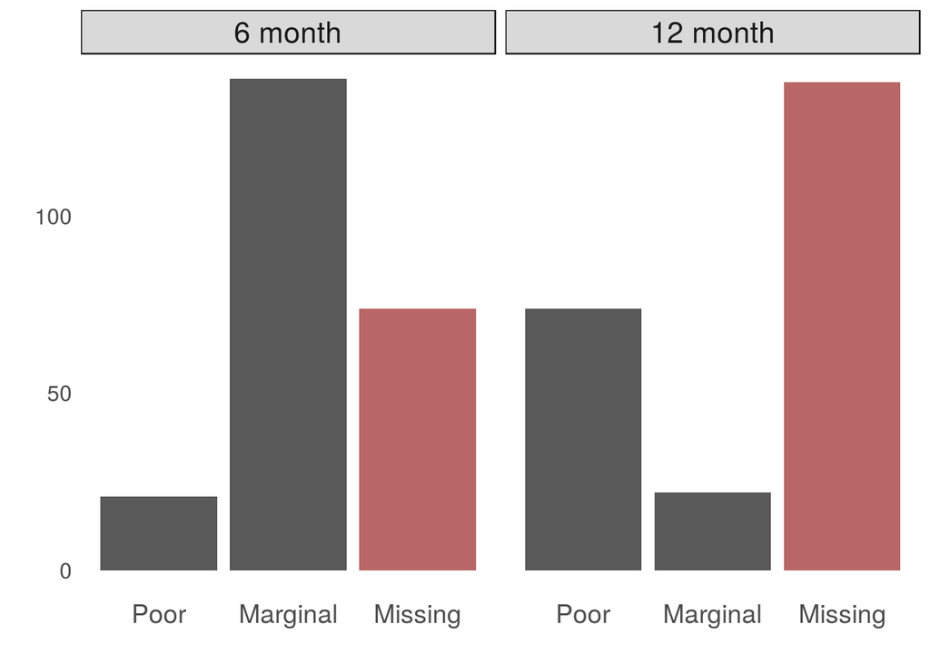

As before, we see that even after collapsing the outcomes to become binary there is still a high degree of class imbalance in the data. We can address this in the modeling procedure by resampling the data in one of many ways:

- **Down-sampling:** Here we take a random subsample of the dominant class (here, `Marginal`) that is the same size as the underrepresented class (`Poor`).
- **Up-sampling**: Here we take bootstrapped resamples with replacement from the underrepresented class, and continue resampling until the size of that class is the same as the size of the dominant class.
- **Hybrid methods**: There are two methods that use algorithms to combine the upsides and downsides of each of the above approaches, and these are implemented in the `caret` package (Kuhn 2008).

Another consideration is the missing data. Most of the data for the 12 month outcome are missing, and we saw in the previous analysis that imputation is simply not possible. Moreover, given our use of resampling methods and cross-validation, I have avoided imputing data for the 6 month outcome for now, since doing so would add a great deal of complexity to the procedure (i.e., imputation would itself occur iteratively at each iteration of the resampling and prediction procedures).

With these considerations in mind, for now I simply use listwise deletion and only focus on the 6 month outcome, since we still have a relatively large sample at this timepoint $(n = 160)$ versus the 12 month follow-up $(n = 96)$.

## Algorithm

1. Resample the data using either down-sampling, up-sampling, or one of the two hybrid methods (SMOTE or ROSE).
2. Create a log-scaled vector of candidate tuning parameters $\lambda$ (defaults to 50), and perform $k$-fold cross-validation (defaults to 10) to evaluate the models, all fit using the hierarchical LASSO.
3. Compute performance metrics for each of the tuning parameters, and choose one to use for selecting a final parameter. Here I use the area under the precision-recall curve, PRC.
4. Repeat this procedure for $B$ iterations.

# Results

## Comparing resampling techniques

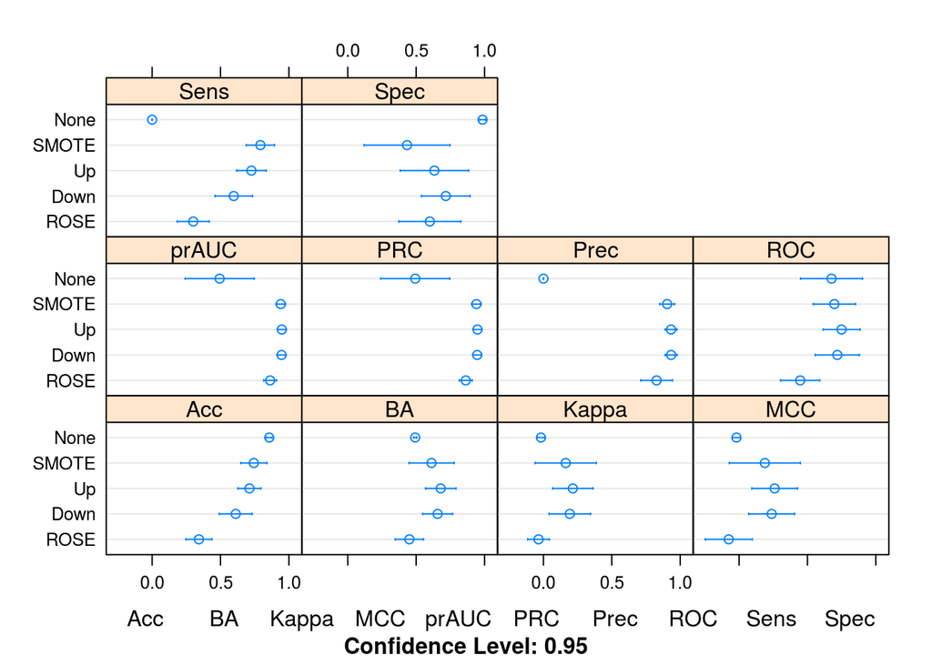

## Choosing a final model

```
##
## Call:
## glm(formula = y ~ ., family = binomial, data = X)
##
## Deviance Residuals:
##     Min       1Q   Median       3Q      Max
## -1.5849  -0.4916  -0.3327  -0.1782   2.8685
##
## Coefficients:
##             Estimate Std. Error z value Pr(>|z|)
## (Intercept)  -2.4325     0.7233  -3.363 0.000771 ***
## EP1           0.4015     0.5628   0.713 0.475641
## EP2           0.4572     0.7363   0.621 0.534624
## I1            1.6377     0.6983   2.345 0.019015 *
## I2           -1.2605     0.8708  -1.448 0.147749
## `EP1:EP2`     1.3753     0.5404   2.545 0.010928 *
## `EP2:I2`     -2.4920     0.8509  -2.929 0.003403 **
## ---
## Signif. codes:  0 '***' 0.001 '**' 0.01 '*' 0.05 '.' 0.1 ' ' 1
##
## (Dispersion parameter for binomial family taken to be 1)
##
##     Null deviance: 124.402  on 159  degrees of freedom
## Residual deviance:  95.573  on 153  degrees of freedom
## AIC: 109.57
##
## Number of Fisher Scoring iterations: 6
```

This final model includes the following predictors (with the labels Kelsie sent):

- **Bulimia** (EP1)
- **Exercise-Focused Behaviors** (EP2)
- **Distress** (I1)
- **Fear** (I2)
- **Bulimia** $\times$ **Exercise-Focused Behaviors**
- **Fear** $\times$ **Exercise-Focused Behaviors**

### Compare with intercept model

```
## Analysis of Deviance Table
##
## Model 1: y ~ 1
## Model 2: y ~ EP1 + EP2 + I1 + I2 + `EP1:EP2` + `EP2:I2`
##   Resid. Df Resid. Dev Df Deviance   Pr(>Chi)
## 1       159    124.402
## 2       153     95.573  6   28.829 0.00006553 ***
## ---
## Signif. codes:  0 '***' 0.001 '**' 0.01 '*' 0.05 '.' 0.1 ' ' 1
```

Final model fits significantly better than the intercept model.

### Compare with no-interaction model

```
## Analysis of Deviance Table
##
## Model 1: y ~ EP1 + EP2 + EP3 + I1 + I2 + I3
## Model 2: y ~ EP1 + EP2 + I1 + I2 + `EP1:EP2` + `EP2:I2`
##   Resid. Df Resid. Dev Df Deviance Pr(>Chi)
## 1       153    109.711
## 2       153     95.573  0   14.138
```

Final model has the same number of parameters, so a $p$-value cannot be calculated, but has lower residual deviance; if there were even one extra degree of freedom, this difference would be significant. Thus, it is appropriate to choose the final model over the no-interaction model.

### Compare with saturated model

```
## Analysis of Deviance Table
##
## Model 1: y ~ (EP1 + EP2 + EP3 + I1 + I2 + I3)^2
## Model 2: y ~ EP1 + EP2 + I1 + I2 + `EP1:EP2` + `EP2:I2`
##   Resid. Df Resid. Dev  Df Deviance Pr(>Chi)
## 1       138     77.761
## 2       153     95.573 -15  -17.812   0.2727
```

There is not a significant difference between the final model and the saturated model based on the LRT. The final model, however, has 15 more degrees of freedom than the saturated model, and is therefore simpler and should be the preferred option.

# References

Bien, Jacob, Jonathan Taylor, and Robert Tibshirani. 2013. “A Lasso for Hierarchical Interactions.” *The Annals of Statistics* 41. NIH Public Access: 1111–41.

Forbush, Kelsie T, Po-Yi Chen, Kelsey E Hagan, Danielle AN Chapa, Sara R Gould, Nicholas R Eaton, and Robert F Krueger. 2018. “A New Approach to Eating-Disorder Classification: Using Empirical Methods to Delineate Diagnostic Dimensions and Inform Care.” *International Journal of Eating Disorders* 51: 710–21.

Kuhn, Max. 2008. “Building Predictive Models in R Using the Caret Package.” *Journal of Statistical Software* 28: 1–26.

Lim, Michael, and Trevor Hastie. 2015. “Learning Interactions via Hierarchical Group-Lasso Regularization.” *Journal of Computational and Graphical Statistics* 24. Taylor & Francis: 627–54.